# Chile Labor Force-Real World Time Series Analysis

Oguzhan Gurbuz

2023-01-30

#The labor force participation rate can be defined as “an estimate of an economy’s active workforce” (Investopedia). The formula is the number of people ages 16 and older who are employed or actively seeking employment, divided by the total non-institutionalized, civilian working-age population. #It is important to understand this rate since it yields a strong clue about the country’s economy.

#Labor Force Participation Rate = (Number Employed+Number Seeking Work) × 100 / Civilian Non-Institutional Population

#In this time series analysis, we’re going to analyse the labor force participation rate trend of a developing country in the Global South, Chile, having a population of 19,5 million according to the World Bank. The main goal of this analysis is to see the current pattern of the country’s labour force partication rate and forecast the next 6 years.

#The data I collected from the World Bank has a time period of 30 years between 1990 and 2019. We’re going to forecast the value for the next 6 years between 2020 and 2025. This will be possible by using three forecast methods, namely, the Box-Jenkins or ARIMA (Autoregressive Integrated Moving Average), Holt’s linear trend and Holt-Winter damped methods.

```r
#Let's install the necessary packages
#install.packages("fpp")
#install.packages("forecast")
#install.packages("ggplot2")

#Let's load the necessary packages.
library(readxl)
library(forecast)
library(ggplot2)
library(fpp)
```

#PREPARING AND EXPLORING THE DATA

```r
#First, we need to load the dataset and assign to "chile_data".
chile_data <- read_excel("Chile Labor Force Participation Rate.xlsx")
```

```r
#What's the class of the Chile data set.
class(chile_data) #It's a data frame.
```

```
## [1] "tbl_df"     "tbl"        "data.frame"
```

```r
#Let's add a name to top of the data
names(chile_data) <- c("Labor Force Participation Rate")
chile_ts <- ts(chile_data, start = 1990,end = 2019,frequency = 1)

#Let's see a few observations from the dataset.
head(chile_ts)
```

```
## Time Series:
## Start = 1990
## End = 1995
## Frequency = 1
##      Labor Force Participation Rate
## [1,]                           58.0
## [2,]                           58.5
## [3,]                           59.1
## [4,]                           59.5
## [5,]                           59.8
## [6,]                           60.4
```

```r
#Summary of the data
summary(chile_data)
```

```
##  Labor Force Participation Rate
##  Min.   :58.00
##  1st Qu.:60.48
##  Median :61.95
##  Mean   :63.42
##  3rd Qu.:67.28
##  Max.   :69.00
```

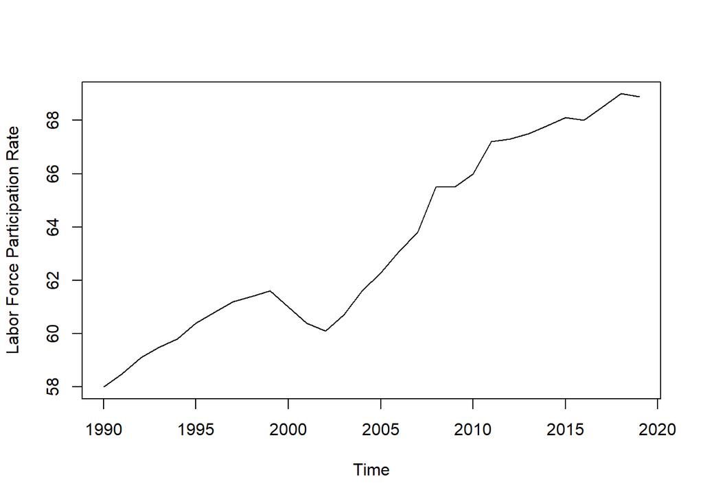

```r
#We can plot the data and see how it increased in time.
plot(chile_ts)
```

```r
#Based on the plot, we can say the labor force participation rate data set seems trending, but apparently, there is no seasonality. That means the Holt function for a linear trend model will be a good one to forecast.
```

#Holt Linear and Holt-Winter’s Models

```r
#Let's set up a linear trend model for the Chile labor participation time series. We can use the holt() function, being a component of the forecast package. The argument h is used to specify the forecast length. For the first observation, let's go with 10 (h = 10). In other words, that is a forecast of 10 years into the future.

# Exponential smoothing with holt-trend

holt.linear = holt(chile_ts, h = 10)

summary(holt.linear)
```

```
##
## Forecast method: Holt's method
##
## Model Information:
## Holt's method
##
## Call:
##  holt(y = chile_ts, h = 10)
##
##   Smoothing parameters:
##     alpha = 0.9999
##     beta  = 0.4021
##
##   Initial states:
##     l = 57.5226
##     b = 0.4805
##
##   sigma:  0.5106
##
##      AIC     AICc      BIC
## 67.41627 69.91627 74.42226
##
## Error measures:
##                       ME      RMSE       MAE         MPE      MAPE      MASE
## Training set -0.02438653 0.4753705 0.3501402 -0.03513517 0.5468293 0.7100745
##                    ACF1
## Training set 0.05602751
##
## Forecasts:
##      Point Forecast    Lo 80    Hi 80    Lo 95    Hi 95
## 2020       69.08635 68.43195 69.74075 68.08553 70.08717
## 2021       69.27265 68.14573 70.39958 67.54917 70.99614
## 2022       69.45895 67.82686 71.09105 66.96288 71.95503
## 2023       69.64526 67.46626 71.82425 66.31277 72.97774
## 2024       69.83156 67.06366 72.59946 65.59842 74.06469
## 2025       70.01786 66.62051 73.41521 64.82207 75.21365
## 2026       70.20416 66.13863 74.26970 63.98646 76.42186
## 2027       70.39046 65.61976 75.16116 63.09431 77.68662
## 2028       70.57677 65.06556 76.08797 62.14810 79.00543
## 2029       70.76307 64.47748 77.04865 61.15010 80.37604
```